# PRACTICAL MACHINE LEARNING COURSE PROJECT

#### Clear Workspace

```r
# Clear All Global Environiment Objects
rm(list = ls())
# Turn off warnings
options(warn=-1)
```

We start by loading the desired packages.

### Load packages

```r
library(ggplot2)
library(dplyr)
library(caret)
```

The first step is to import the data.

### Load Data

```r
## Read Data
df_training= read.csv("pml-training.csv")
df_testing= read.csv("pml-testing.csv")
```

Next we check for training and testing data consistency, i.e. check if schema of both the training and testing sets are identical.

```r
colnames_train <- colnames(df_training)
colnames_test <- colnames(df_testing)

# Verify that the column names (excluding classe and problem_id) are identical in the training and test set.
all.equal(colnames_train[1:length(colnames_train)-1], colnames_test[1:length(colnames_train)-1])
```

```
## [1] TRUE
```

Hence we confirm that the schema is identical.

Next we eliminate features with NAs

```r
# Count the number of non-NAs in each col.
nonNAs <- function(x) {
    as.vector(apply(x, 2, function(x) length(which(!is.na(x)))))
}

# Build vector of missing data or NA columns to drop.
colcnts <- nonNAs(df_training)
drops <- c()
for (cnt in 1:length(colcnts)) {
    if (colcnts[cnt] < nrow(df_training)) {
        drops <- c(drops, colnames_train[cnt])  # names of columns to drop
    }
}



# Drop NA data and the first 7 columns as they're unnecessary for predicting.
df_training <- df_training[,!(names(df_training) %in% drops)]
df_training <- df_training[,8:length(colnames(df_training))]

df_testing <- df_testing[,!(names(df_testing) %in% drops)]
df_testing <- df_testing[,8:length(colnames(df_testing))]

# Show remaining columns.
colnames(df_training)
```

```
##  [1] "roll_belt"               "pitch_belt"
##  [3] "yaw_belt"                "total_accel_belt"
##  [5] "kurtosis_roll_belt"      "kurtosis_picth_belt"
##  [7] "kurtosis_yaw_belt"       "skewness_roll_belt"
##  [9] "skewness_roll_belt.1"    "skewness_yaw_belt"
## [11] "max_yaw_belt"            "min_yaw_belt"
## [13] "amplitude_yaw_belt"      "gyros_belt_x"
## [15] "gyros_belt_y"            "gyros_belt_z"
## [17] "accel_belt_x"            "accel_belt_y"
## [19] "accel_belt_z"            "magnet_belt_x"
## [21] "magnet_belt_y"           "magnet_belt_z"
## [23] "roll_arm"                "pitch_arm"
## [25] "yaw_arm"                 "total_accel_arm"
## [27] "gyros_arm_x"             "gyros_arm_y"
## [29] "gyros_arm_z"             "accel_arm_x"
```

[output cut: 28 more lines]

```r
colnames(df_testing)
```

```
##  [1] "roll_belt"               "pitch_belt"
##  [3] "yaw_belt"                "total_accel_belt"
##  [5] "kurtosis_roll_belt"      "kurtosis_picth_belt"
##  [7] "kurtosis_yaw_belt"       "skewness_roll_belt"
##  [9] "skewness_roll_belt.1"    "skewness_yaw_belt"
## [11] "max_yaw_belt"            "min_yaw_belt"
## [13] "amplitude_yaw_belt"      "gyros_belt_x"
## [15] "gyros_belt_y"            "gyros_belt_z"
## [17] "accel_belt_x"            "accel_belt_y"
## [19] "accel_belt_z"            "magnet_belt_x"
## [21] "magnet_belt_y"           "magnet_belt_z"
## [23] "roll_arm"                "pitch_arm"
## [25] "yaw_arm"                 "total_accel_arm"
## [27] "gyros_arm_x"             "gyros_arm_y"
## [29] "gyros_arm_z"             "accel_arm_x"
```

[output cut: 28 more lines]

Need we check if there are any near zero varaiance predictors and eliminate them

```r
nsv <- nearZeroVar(df_training, saveMetrics=TRUE)
nsv
```

```
##                           freqRatio percentUnique zeroVar   nzv
## roll_belt                  1.101904    6.77810621   FALSE FALSE
## pitch_belt                 1.036082    9.37722964   FALSE FALSE
## yaw_belt                   1.058480    9.97349913   FALSE FALSE
## total_accel_belt           1.063160    0.14779329   FALSE FALSE
## kurtosis_roll_belt      1921.600000    2.02323922   FALSE  TRUE
## kurtosis_picth_belt      600.500000    1.61553358   FALSE  TRUE
## kurtosis_yaw_belt         47.330049    0.01019264   FALSE  TRUE
## skewness_roll_belt      2135.111111    2.01304658   FALSE  TRUE
## skewness_roll_belt.1     600.500000    1.72255631   FALSE  TRUE
## skewness_yaw_belt         47.330049    0.01019264   FALSE  TRUE
## max_yaw_belt             640.533333    0.34654979   FALSE  TRUE
## min_yaw_belt             640.533333    0.34654979   FALSE  TRUE
## amplitude_yaw_belt        50.041667    0.02038528   FALSE  TRUE
## gyros_belt_x               1.058651    0.71348486   FALSE FALSE
## gyros_belt_y               1.144000    0.35164611   FALSE FALSE
## gyros_belt_z               1.066214    0.86127816   FALSE FALSE
## accel_belt_x               1.055412    0.83579655   FALSE FALSE
## accel_belt_y               1.113725    0.72877383   FALSE FALSE
## accel_belt_z               1.078767    1.52379982   FALSE FALSE
## magnet_belt_x              1.090141    1.66649679   FALSE FALSE
## magnet_belt_y              1.099688    1.51870350   FALSE FALSE
## magnet_belt_z              1.006369    2.32901845   FALSE FALSE
## roll_arm                  52.338462   13.52563449   FALSE FALSE
## pitch_arm                 87.256410   15.73234125   FALSE FALSE
## yaw_arm                   33.029126   14.65701763   FALSE FALSE
## total_accel_arm            1.024526    0.33635715   FALSE FALSE
## gyros_arm_x                1.015504    3.27693405   FALSE FALSE
## gyros_arm_y                1.454369    1.91621649   FALSE FALSE
## gyros_arm_z                1.110687    1.26388747   FALSE FALSE
## accel_arm_x                1.017341    3.95984099   FALSE FALSE
## accel_arm_y                1.140187    2.73672409   FALSE FALSE
## accel_arm_z                1.128000    4.03628580   FALSE FALSE
## magnet_arm_x               1.000000    6.82397309   FALSE FALSE
## magnet_arm_y               1.056818    4.44399144   FALSE FALSE
## magnet_arm_z               1.036364    6.44684538   FALSE FALSE
## kurtosis_roll_arm        246.358974    1.68178575   FALSE  TRUE
## kurtosis_picth_arm       240.200000    1.67159311   FALSE  TRUE
## kurtosis_yaw_arm        1746.909091    2.01304658   FALSE  TRUE
## skewness_roll_arm        249.558442    1.68688207   FALSE  TRUE
```

[output cut: 32 more lines]

```
## skewness_yaw_forearm      47.330049    0.01019264   FALSE  TRUE
## max_yaw_forearm          228.761905    0.22933442   FALSE  TRUE
## min_yaw_forearm          228.761905    0.22933442   FALSE  TRUE
## amplitude_yaw_forearm     59.677019    0.01528896   FALSE  TRUE
## total_accel_forearm        1.128928    0.35674243   FALSE FALSE
## gyros_forearm_x            1.059273    1.51870350   FALSE FALSE
## gyros_forearm_y            1.036554    3.77637346   FALSE FALSE
## gyros_forearm_z            1.122917    1.56457038   FALSE FALSE
## accel_forearm_x            1.126437    4.04647844   FALSE FALSE
## accel_forearm_y            1.059406    5.11160942   FALSE FALSE
## accel_forearm_z            1.006250    2.95586586   FALSE FALSE
## magnet_forearm_x           1.012346    7.76679238   FALSE FALSE
## magnet_forearm_y           1.246914    9.54031189   FALSE FALSE
## magnet_forearm_z           1.000000    8.57710733   FALSE FALSE
## classe                     1.469581    0.02548160   FALSE FALSE
```

```r
nsv <- nearZeroVar(df_training)

if (length(nsv)>0){

df_training <- df_training[, -nsv]
df_testing <- df_testing[, -nsv]


}
```

Now we fit a classification model.

We start by fitting a decision tree based model. Training is done with preprocessing (centering and scaling) and 5-cross validation.

Even though we have been provided with a test set of 20 samples, we first divide the training dataset into a train and test data set in the proportion 75:25.

Next we train the model

CARET PACKAGE - CART - Classification and Decision Tree

```r
set.seed(333)
# create training set indexes with 75% of data
inTrain <- createDataPartition(y=df_training$classe,p=0.75, list=FALSE)
#  training set
training <- df_training[inTrain,]
# testing set
testing <- df_training[-inTrain,]


# dimension of original and training dataset & training dataset
rbind("original dataset" = dim(df_training),"training set" = dim(training),"testing set" = dim(testing))
```

```
##                   [,1] [,2]
## original dataset 19622   53
## training set     14718   53
## testing set       4904   53
```

```r
set.seed(333)
# Train on training  with both preprocessing and cross validation.
modFit <- train(classe ~ .,  preProcess=c("center", "scale"), trControl=trainControl(method = "cv", number = 5), data = training, method="rpart")
print(modFit, digits=3)
```

```
## CART
##
## 14718 samples
##    52 predictor
##     5 classes: 'A', 'B', 'C', 'D', 'E'
##
## Pre-processing: centered (52), scaled (52)
## Resampling: Cross-Validated (5 fold)
## Summary of sample sizes: 11775, 11774, 11773, 11776, 11774
## Resampling results across tuning parameters:
##
##   cp      Accuracy  Kappa
##   0.0323  0.504     0.3522
##   0.0595  0.440     0.2500
##   0.1144  0.332     0.0732
##
## Accuracy was used to select the optimal model using  the largest value.
## The final value used for the model was cp = 0.0323.
```

```r
library(rattle)
```

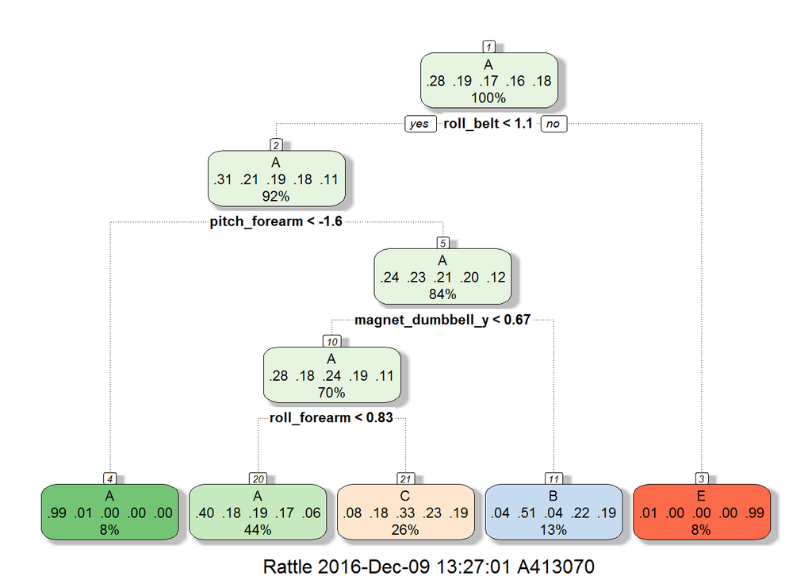

```r
library(rpart.plot)
fancyRpartPlot(modFit$finalModel)
```

Accuracy of the trained model is checked on the 25% test set.

Prediction

```r
pred <- predict(modFit,testing)
cfMatrix <- confusionMatrix(data = pred,testing$classe)
print(cfMatrix, digits = 4)
```

```
## Confusion Matrix and Statistics
##
##           Reference
## Prediction    A    B    C    D    E
##          A 1279  398  381  335  130
##          B   19  316   23  152  118
##          C   94  235  451  317  238
##          D    0    0    0    0    0
##          E    3    0    0    0  415
##
## Overall Statistics
##
##                Accuracy : 0.5018
##                  95% CI : (0.4877, 0.5159)
##     No Information Rate : 0.2845
##     P-Value [Acc > NIR] : < 2.2e-16
##
##                   Kappa : 0.3494
##  Mcnemar's Test P-Value : NA
##
## Statistics by Class:
##
##                      Class: A Class: B Class: C Class: D Class: E
## Sensitivity            0.9168  0.33298  0.52749   0.0000  0.46060
## Specificity            0.6455  0.92111  0.78167   1.0000  0.99925
## Pos Pred Value         0.5069  0.50318  0.33783      NaN  0.99282
## Neg Pred Value         0.9513  0.85196  0.88680   0.8361  0.89166
## Prevalence             0.2845  0.19352  0.17435   0.1639  0.18373
## Detection Rate         0.2608  0.06444  0.09197   0.0000  0.08462
## Detection Prevalence   0.5145  0.12806  0.27223   0.0000  0.08524
## Balanced Accuracy      0.7812  0.62705  0.65458   0.5000  0.72992
```

Model accuracy is found to be 50.18%, which is unsatifactory.

Next we try a more advanced classification algorithm based on random forests.

CARET PACKAGE - Random Forest

```r
set.seed(333)
modFit_rf <- train(classe ~ ., method="rf", preProcess=c("center", "scale"), trControl=trainControl(method = "cv", number = 5), data=training)
print(modFit_rf, digits=3)
```

```
## Random Forest
##
## 14718 samples
##    52 predictor
##     5 classes: 'A', 'B', 'C', 'D', 'E'
##
## Pre-processing: centered (52), scaled (52)
## Resampling: Cross-Validated (5 fold)
## Summary of sample sizes: 11775, 11774, 11773, 11776, 11774
## Resampling results across tuning parameters:
##
##   mtry  Accuracy  Kappa
##    2    0.992     0.990
##   27    0.991     0.988
##   52    0.985     0.981
##
## Accuracy was used to select the optimal model using  the largest value.
## The final value used for the model was mtry = 2.
```

Varimp plot

```r
print(modFit_rf, digits = 4)
```

```
## Random Forest
##
## 14718 samples
##    52 predictor
##     5 classes: 'A', 'B', 'C', 'D', 'E'
##
## Pre-processing: centered (52), scaled (52)
## Resampling: Cross-Validated (5 fold)
## Summary of sample sizes: 11775, 11774, 11773, 11776, 11774
## Resampling results across tuning parameters:
##
##   mtry  Accuracy  Kappa
##    2    0.9923    0.9902
##   27    0.9906    0.9881
##   52    0.9850    0.9810
##
## Accuracy was used to select the optimal model using  the largest value.
## The final value used for the model was mtry = 2.
```

```r
print(modFit_rf$finalModel)
```

```
##
## Call:
##  randomForest(x = x, y = y, mtry = param$mtry)
##                Type of random forest: classification
##                      Number of trees: 500
## No. of variables tried at each split: 2
##
##         OOB estimate of  error rate: 0.61%
## Confusion matrix:
##      A    B    C    D    E  class.error
## A 4183    2    0    0    0 0.0004778973
## B   13 2829    6    0    0 0.0066713483
## C    0   19 2546    2    0 0.0081807557
## D    0    0   41 2368    3 0.0182421227
## E    0    0    1    3 2702 0.0014781966
```

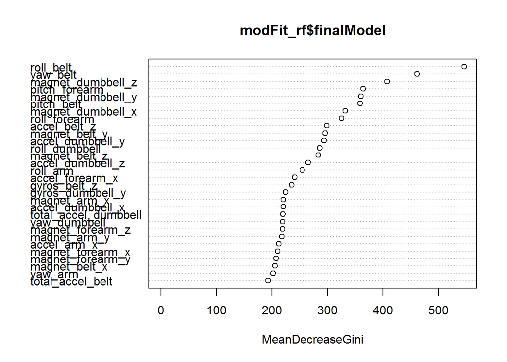

```r
varImpPlot(modFit_rf$finalModel)
```

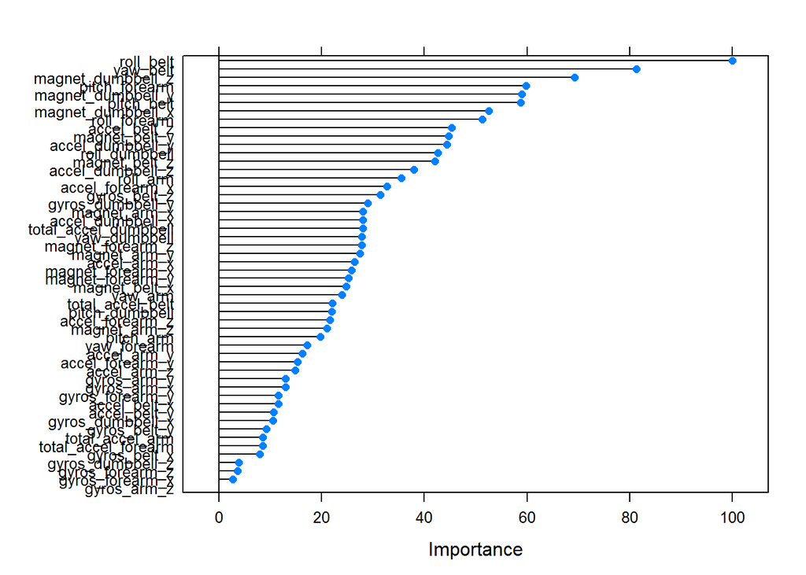

```r
plot(varImp(modFit_rf))
```

Prediction

```r
modFit_rf
```

```
## Random Forest
##
## 14718 samples
##    52 predictor
##     5 classes: 'A', 'B', 'C', 'D', 'E'
##
## Pre-processing: centered (52), scaled (52)
## Resampling: Cross-Validated (5 fold)
## Summary of sample sizes: 11775, 11774, 11773, 11776, 11774
## Resampling results across tuning parameters:
##
##   mtry  Accuracy   Kappa
##    2    0.9922544  0.9902009
##   27    0.9905559  0.9880532
##   52    0.9849842  0.9810046
##
## Accuracy was used to select the optimal model using  the largest value.
## The final value used for the model was mtry = 2.
```

```r
pred_rf <- predict(modFit_rf,testing)
cfMatrix <- confusionMatrix(data = pred_rf,testing$classe)
print(cfMatrix, digits = 4)
```

```
## Confusion Matrix and Statistics
##
##           Reference
## Prediction    A    B    C    D    E
##          A 1395    5    0    0    0
##          B    0  940    3    0    0
##          C    0    4  850    9    2
##          D    0    0    2  795    2
##          E    0    0    0    0  897
##
## Overall Statistics
##
##                Accuracy : 0.9945
##                  95% CI : (0.992, 0.9964)
##     No Information Rate : 0.2845
##     P-Value [Acc > NIR] : < 2.2e-16
##
##                   Kappa : 0.993
##  Mcnemar's Test P-Value : NA
##
## Statistics by Class:
##
##                      Class: A Class: B Class: C Class: D Class: E
## Sensitivity            1.0000   0.9905   0.9942   0.9888   0.9956
## Specificity            0.9986   0.9992   0.9963   0.9990   1.0000
## Pos Pred Value         0.9964   0.9968   0.9827   0.9950   1.0000
## Neg Pred Value         1.0000   0.9977   0.9988   0.9978   0.9990
## Prevalence             0.2845   0.1935   0.1743   0.1639   0.1837
## Detection Rate         0.2845   0.1917   0.1733   0.1621   0.1829
## Detection Prevalence   0.2855   0.1923   0.1764   0.1629   0.1829
## Balanced Accuracy      0.9993   0.9949   0.9952   0.9939   0.9978
```

```r
confusionMatrix(data = pred_rf,testing$classe)$overall[1]
```

```
##  Accuracy
## 0.9944943
```

Ultimately, the prediction model was run on the test data to predict the outcome of 20 different test cases.

```r
print(predict(modFit_rf, newdata=df_testing))
```

```
##  [1] B A B A A E D B A A B C B A E E A B B B
## Levels: A B C D E
```